# Lab 4: Performance Mining & Managerial Memo

CRISP-DM Phase 5 & 6 — Evaluation & Deployment

Autor:in

Prof. Dr. Jörg Schoder

Veröffentlichungsdatum

18. März 2026

## 1 Lernziele und Überblick

**HinweisLernziele dieses Labs**

- Das multiple Regressionsmodell als **Scoring-Instrument** einsetzen
- **Residuen** als quantitatives Underperformance-Maß berechnen und ranken
- Ergebnisse im **Managerial Memo** managementtauglich kommunizieren (Translator-Rolle)
- Die Grenzen des Modells kritisch reflektieren: R², OVB, **Data Drought**, Make-or-Buy

**TippZeitplanung**

⏱ **15 Min.** Pflichtaufgaben A1–A3 | **15 Min.** Gruppenarbeit Managerial Memo

## 2 Hintergrundmaterial: Vertiefung multiple Regression

Dieses Kapitel enthält ergänzendes Hintergrundmaterial, das Sie vor oder nach dem Lab lesen können. Es vertieft die Konzepte aus der Live-Demo anhand weiterer Datensätze.

**Simpson’s Paradoxon**

**Das Problem:** Ein aggregierter Trend kann dem Trend innerhalb von Subgruppen entgegengesetzt sein — wenn ein Confounder beide beeinflusst.

**Code anzeigen**

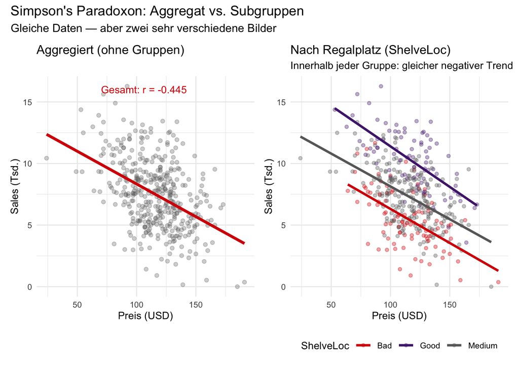

```r
p_agg <- tbl_carseats %>%
  ggplot(aes(x = Price, y = Sales)) +
  geom_point(alpha = 0.3, color = "#686868", size = 1.5) +
  geom_smooth(method = "lm", color = "#D50006",
              se = FALSE, linewidth = 1.3) +
  annotate("text", x = 70, y = 16,
           label = paste0("Gesamt: r = ",
                          round(cor(tbl_carseats$Price,
                                    tbl_carseats$Sales), 3)),
           color = "#D50006", size = 3.5, hjust = 0) +
  labs(title = "Aggregiert (ohne Gruppen)",
       x = "Preis (USD)", y = "Sales (Tsd.)") +
  theme_minimal(base_size = 10)

p_grp <- tbl_carseats %>%
  ggplot(aes(x = Price, y = Sales, color = ShelveLoc)) +
  geom_point(alpha = 0.35, size = 1.3) +
  geom_smooth(method = "lm", se = FALSE, linewidth = 1.1) +
  scale_color_manual(values = c("Bad"    = "#D50006",
                                "Medium" = "#686868",
                                "Good"   = "#502479")) +
  labs(title = "Nach Regalplatz (ShelveLoc)",
       subtitle = "Innerhalb jeder Gruppe: gleicher negativer Trend",
       x = "Preis (USD)", y = "Sales (Tsd.)",
       color = "ShelveLoc") +
  theme_minimal(base_size = 10) +
  theme(legend.position = "bottom")

(p_agg + p_grp) +
  plot_annotation(
    title    = "Simpson's Paradoxon: Aggregat vs. Subgruppen",
    subtitle = "Gleiche Daten — aber zwei sehr verschiedene Bilder"
  )
```

**Takeaway:** Immer nach Confoundern suchen und Subgruppenanalysen durchführen, bevor Sie Aggregate interpretieren. Das multiple Modell löst dieses Problem, indem es für ShelveLoc *kontrolliert*.

**Kategoriale Regression (Gapminder)**

**Wie werden Dummy-Variablen interpretiert?** Das folgende Beispiel mit dem Gapminder-Datensatz zeigt die Logik anhand von Kontinenten — direkt übertragbar auf ShelveLoc.

**Code anzeigen**

```r
gapminder2007 <- gapminder %>%
  filter(year == 2007) %>%
  select(country, continent, lifeExp, gdpPercap)

# Deskriptive Statistiken
gapminder2007 %>%
  group_by(continent) %>%
  summarise(
    n            = n(),
    mean_lifeExp = round(mean(lifeExp), 1),
    sd_lifeExp   = round(sd(lifeExp),   1)
  ) %>%
  arrange(mean_lifeExp) %>%
  gt() %>%
  tab_style(
    style     = cell_fill(color = "#fff8e1"),
    locations = cells_body(rows = continent == "Africa")
  ) %>%
  tab_options(table.font.size = "13px") %>%
  tab_footnote("Gelb = Referenzkategorie (alphabetisch erste Kategorie)")
```

| continent | n | mean_lifeExp | sd_lifeExp |
| --- | --- | --- | --- |
| Africa | 52 | 54.8 | 9.6 |
| Asia | 33 | 70.7 | 8.0 |
| Americas | 25 | 73.6 | 4.4 |
| Europe | 30 | 77.6 | 3.0 |
| Oceania | 2 | 80.7 | 0.7 |

Gelb = Referenzkategorie (alphabetisch erste Kategorie)

**Code anzeigen**

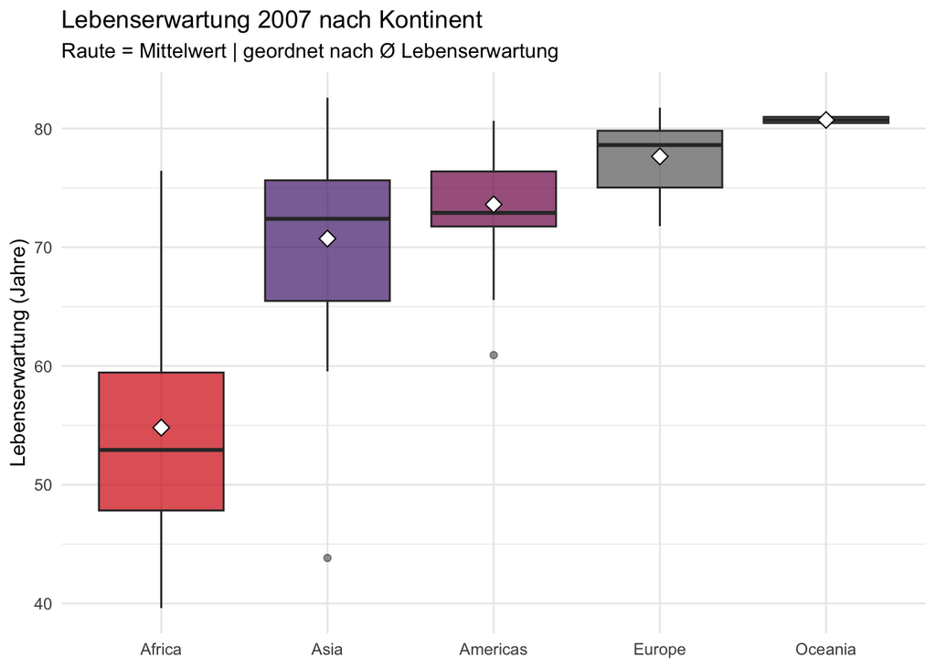

```r
gapminder2007 %>%
  ggplot(aes(x = reorder(continent, lifeExp),
             y = lifeExp, fill = continent)) +
  geom_boxplot(alpha = 0.7, outlier.alpha = 0.5) +
  stat_summary(fun = mean, geom = "point",
               shape = 23, size = 3, fill = "white") +
  scale_fill_manual(values = c(
    "Africa"   = "#D50006", "Americas" = "#7d0a52",
    "Asia"     = "#502479", "Europe"   = "#686868",
    "Oceania"  = "#b3b2b2"
  )) +
  labs(title   = "Lebenserwartung 2007 nach Kontinent",
       subtitle = "Raute = Mittelwert | geordnet nach Ø Lebenserwartung",
       x = NULL, y = "Lebenserwartung (Jahre)") +
  theme_minimal(base_size = 11) +
  theme(legend.position = "none")
```

**Code anzeigen**

```r
mod_lifeexp <- gapminder2007 %>%
  lm(lifeExp ~ continent, data = .)

mod_lifeexp %>%
  get_regression_table() %>%
  gt() %>%
  fmt_number(columns = c(estimate, std_error,
                         statistic, p_value,
                         lower_ci, upper_ci),
             decimals = 2) %>%
  tab_style(
    style     = cell_fill(color = "#fff8e1"),
    locations = cells_body(rows = term == "(Intercept)")
  ) %>%
  tab_style(
    style     = cell_fill(color = "#f5f0fa"),
    locations = cells_body(rows = term != "(Intercept)")
  ) %>%
  tab_options(table.font.size = "13px") %>%
  tab_header(
    "Regression: lifeExp ~ continent",
    subtitle = "Intercept = Ø Afrika | Alle anderen = Differenz zu Afrika"
  )
```

Regression: lifeExp ~ continent

Intercept = Ø Afrika | Alle anderen = Differenz zu Afrika

| term | estimate | std_error | statistic | p_value | lower_ci | upper_ci |
| --- | --- | --- | --- | --- | --- | --- |
| intercept | 54.81 | 1.02 | 53.45 | 0.00 | 52.78 | 56.83 |
| continent: Americas | 18.80 | 1.80 | 10.45 | 0.00 | 15.24 | 22.36 |
| continent: Asia | 15.92 | 1.65 | 9.68 | 0.00 | 12.67 | 19.18 |
| continent: Europe | 22.84 | 1.70 | 13.47 | 0.00 | 19.49 | 26.20 |
| continent: Oceania | 25.91 | 5.33 | 4.86 | 0.00 | 15.38 | 36.45 |

**Koeffizienteninterpretation (direkt auf Carseats übertragbar):**

| Gapminder | Carseats |
| --- | --- |
| Intercept = Ø Lebenserwartung Afrika (Referenz) | Intercept = Ø Sales bei Bad (Referenz) |
| `continentAmericas` = Differenz Americas − Afrika | `ShelveLocGood` = Differenz Good − Bad |
| Referenz kommt alphabetisch zuerst | Referenz kommt alphabetisch zuerst |

**Numerisch nachprüfen:**

**Code anzeigen**

```r
# Intercept = Ø lifeExp Afrika
gapminder2007 %>%
  filter(continent == "Africa") %>%
  summarise(mean_africa = round(mean(lifeExp), 2))
```

```
# A tibble: 1 × 1
  mean_africa
        <dbl>
1        54.8
```

**Code anzeigen**

```r
# Intercept + ShelveLocGood = Ø Americas
coef(mod_lifeexp)["(Intercept)"] +
  coef(mod_lifeexp)["continentAmericas"]
```

```
(Intercept)
   73.60812
```

**Code anzeigen**

```r
gapminder2007 %>%
  filter(continent == "Americas") %>%
  summarise(mean_americas = round(mean(lifeExp), 2))
```

```
# A tibble: 1 × 1
  mean_americas
          <dbl>
1          73.6
```

**Multiple Regression: 2 numerische Regressoren**

**Konzept:** Bei zwei numerischen Regressoren schätzt OLS keine Gerade, sondern eine **Ebene** im dreidimensionalen Raum.

Das folgende Beispiel nutzt Kreditkartendaten aus ISLR2.

**Code anzeigen**

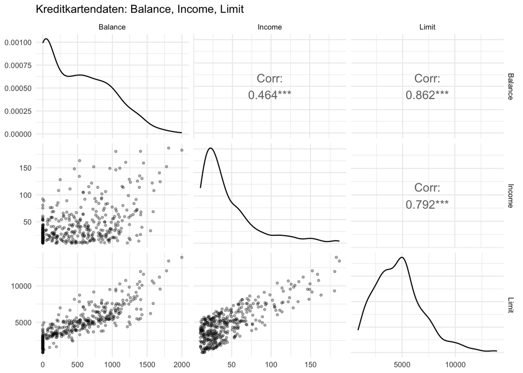

```r
tbl_credit <- tibble(Credit) %>%
  select(Balance, Income, Limit, Rating, Age)

# Streudiagramm-Matrix
tbl_credit %>%
  select(Balance, Income, Limit) %>%
  ggpairs(
    upper   = list(continuous = wrap("cor", size = 4)),
    lower   = list(continuous = wrap("points",
                                     alpha = 0.3, size = 0.8)),
    diag    = list(continuous = wrap("densityDiag", alpha = 0.6)),
    progress = FALSE
  ) +
  theme_minimal(base_size = 9) +
  labs(title = "Kreditkartendaten: Balance, Income, Limit")
```

**Code anzeigen**

```r
mod_credit <- tbl_credit %>%
  lm(Balance ~ Income + Limit, data = .)

mod_credit %>%
  get_regression_table() %>%
  gt() %>%
  fmt_number(columns = c(estimate, std_error,
                         statistic, p_value,
                         lower_ci, upper_ci),
             decimals = 4) %>%
  tab_style(
    style     = cell_fill(color = "#fff8e1"),
    locations = cells_body(rows = term != "(Intercept)")
  ) %>%
  tab_options(table.font.size = "13px") %>%
  tab_header(
    "Multiple Regression: Balance ~ Income + Limit",
    subtitle = "Beide Koeffizienten: ceteris paribus"
  )
```

Multiple Regression: Balance ~ Income + Limit

Beide Koeffizienten: ceteris paribus

| term | estimate | std_error | statistic | p_value | lower_ci | upper_ci |
| --- | --- | --- | --- | --- | --- | --- |
| intercept | −385.1790 | 19.4650 | −19.7890 | 0.0000 | −423.4460 | −346.9120 |
| Income | −7.6630 | 0.3850 | −19.9010 | 0.0000 | −8.4200 | −6.9060 |
| Limit | 0.2640 | 0.0060 | 44.9550 | 0.0000 | 0.2530 | 0.2760 |

**Interpretation der Koeffizienten:**

- **Income** (-7.6633): 1.000 USD mehr Einkommen → Kreditkartensaldo ändert sich um -7.66 USD, **ceteris paribus** (Limit konstant).
- **Limit** (0.2643): 1 USD mehr Kreditlimit → Saldo ändert sich um 0.2643 USD, **ceteris paribus** (Income konstant).

**Code anzeigen**

```r
mod_credit %>%
  get_regression_summaries() %>%
  select(r_squared, adj_r_squared, rmse) %>%
  gt() %>%
  fmt_number(decimals = 4) %>%
  tab_options(table.font.size = "13px")
```

| r_squared | adj_r_squared | rmse |
| --- | --- | --- |
| 0.8710 | 0.8700 | 164.8547 |

**Übertragung auf Carseats:** Das Carseats-Modell kombiniert *numerische* Regressoren (Price, Advertising) mit einem *kategorialen* Regressor (ShelveLoc) — das ist der allgemeine Fall der multiplen Regression.

## 3 Aufgaben: Performance Mining

### 3.1 Schritt 1 — Modell rekapitulieren

Das multiple Modell aus der Live-Demo:

```r
# Modell identisch zur Demo
mod_multipel <- tbl_carseats %>%
  lm(Sales ~ Price + Advertising + ShelveLoc, data = .)

# Modellgüte
mod_multipel %>%
  get_regression_summaries() %>%
  select(r_squared, adj_r_squared, rmse, sigma, nobs) %>%
  gt() %>%
  fmt_number(columns = c(r_squared, adj_r_squared, rmse, sigma),
             decimals = 4) %>%
  tab_options(table.font.size = "14px")
```

| r_squared | adj_r_squared | rmse | sigma | nobs |
| --- | --- | --- | --- | --- |
| 0.6080 | 0.6050 | 1.7649 | 1.7760 | 400 |

**Code anzeigen**

```r
# Koeffizienten für den Einstieg
mod_multipel %>%
  get_regression_table() %>%
  gt() %>%
  fmt_number(columns = c(estimate, std_error,
                         statistic, p_value,
                         lower_ci, upper_ci),
             decimals = 4) %>%
  tab_style(
    style     = cell_fill(color = "#f5f0fa"),
    locations = cells_body(rows = str_detect(term, "ShelveLoc"))
  ) %>%
  tab_options(table.font.size = "13px")
```

| term | estimate | std_error | statistic | p_value | lower_ci | upper_ci |
| --- | --- | --- | --- | --- | --- | --- |
| intercept | 11.4680 | 0.4710 | 24.3520 | 0.0000 | 10.5420 | 12.3940 |
| Price | −0.0580 | 0.0040 | −15.4040 | 0.0000 | −0.0650 | −0.0510 |
| Advertising | 0.1090 | 0.0130 | 8.1540 | 0.0000 | 0.0830 | 0.1360 |
| ShelveLoc: Good | 4.7760 | 0.2650 | 18.0070 | 0.0000 | 4.2550 | 5.2980 |
| ShelveLoc: Medium | 1.8290 | 0.2170 | 8.4090 | 0.0000 | 1.4010 | 2.2560 |

### 3.2 Schritt 2 — Performance-Scores berechnen

```r
filial_scored <- mod_multipel %>%
  get_regression_points() %>%
  mutate(
    performance_gap = residual,
    performance_kat = case_when(
      residual < -2 ~ "Underperformer",
      residual >  2 ~ "Outperformer",
      TRUE          ~ "Normal"
    )
  )

# Überblick
filial_scored %>%
  count(performance_kat) %>%
  mutate(anteil = scales::percent(n / sum(n), accuracy = 0.1)) %>%
  arrange(desc(n)) %>%
  gt() %>%
  tab_options(table.font.size = "13px")
```

| performance_kat | n | anteil |
| --- | --- | --- |
| Normal | 293 | 73.2% |
| Outperformer | 56 | 14.0% |
| Underperformer | 51 | 12.8% |

**HinweisResiduum = Underperformance-Maß**

$$e_i = \text{Sales}_i - \widehat{\text{Sales}}_i$$

- $e_i \ll 0$: Filiale verkauft **deutlich weniger** als der Benchmark — **Underperformer**
- $e_i \approx 0$: Filiale liegt im Marktdurchschnitt
- $e_i \gg 0$: Filiale verkauft **mehr** als erwartet — **Outperformer**

**Wichtig:** Der Benchmark ist bereits für Preis, Werbung und Regalplatz *bereinigt* — ein Underperformer ist also wirklich schlechter als Filialen mit vergleichbaren Ausgangsbedingungen.

### 3.3 Schritt 3 — Top-10-Underperformer-Ranking

**Code anzeigen**

```r
# Metadaten für Unternehmenskontext ergänzen
filial_scored %>%
  arrange(performance_gap) %>%
  head(10) %>%
  left_join(
    tbl_carseats %>%
      mutate(ID = row_number()) %>%
      select(ID, ShelveLoc, Urban, US, Income, Age),
    by = "ID"
  ) %>%
  select(ID, Sales, Sales_hat, performance_gap,
         ShelveLoc.x, Urban, US, Income, Age) %>%
  rename(ShelveLoc = ShelveLoc.x) %>%
  gt() %>%
  fmt_number(columns = c(Sales, Sales_hat, performance_gap),
             decimals = 2) %>%
  fmt_number(columns = c(Income, Age), decimals = 0) %>%
  tab_style(
    style     = cell_fill(color = "#fff0f0"),
    locations = cells_body(rows = performance_gap < -3)
  ) %>%
  tab_style(
    style     = cell_fill(color = "#fff8e1"),
    locations = cells_body(rows = performance_gap >= -3 &
                             performance_gap < -2)
  ) %>%
  tab_options(table.font.size = "12px") %>%
  tab_header(
    "Top-10-Underperformer",
    subtitle = "Dunkelrot: gap < −3 | Gelb: gap zwischen −3 und −2"
  )
```

Top-10-Underperformer

Dunkelrot: gap < −3 | Gelb: gap zwischen −3 und −2

| ID | Sales | Sales_hat | performance_gap | ShelveLoc | Urban | US | Income | Age |
| --- | --- | --- | --- | --- | --- | --- | --- | --- |
| 51 | 1.42 | 7.17 | −5.75 | Bad | Yes | Yes | 32 | 80 |
| 107 | 0.16 | 5.24 | −5.08 | Medium | No | No | 33 | 70 |
| 210 | 3.02 | 7.45 | −4.43 | Bad | No | Yes | 21 | 76 |
| 45 | 4.16 | 8.45 | −4.29 | Medium | Yes | Yes | 79 | 69 |
| 101 | 4.11 | 8.35 | −4.24 | Medium | No | Yes | 69 | 76 |
| 298 | 3.07 | 6.86 | −3.79 | Bad | Yes | Yes | 83 | 75 |
| 58 | 0.91 | 4.68 | −3.77 | Bad | Yes | No | 91 | 75 |
| 333 | 5.74 | 9.45 | −3.71 | Medium | Yes | Yes | 33 | 61 |
| 224 | 3.45 | 7.03 | −3.58 | Medium | Yes | Yes | 45 | 62 |
| 92 | 4.81 | 8.30 | −3.49 | Medium | Yes | Yes | 46 | 80 |

**Vorsicht A1 — Underperformer analysieren**

**1.** Welche **ShelveLoc-Kategorie** dominiert die Top-10-Underperformer? Prüfen Sie das empirisch:

```r
filial_scored %>%
  left_join(
    tbl_carseats %>% mutate(ID = row_number()) %>%
      select(ID, ShelveLoc),
    by = "ID"
  ) %>%
  filter(performance_kat == "Underperformer") %>%
  count(ShelveLoc) %>%
  mutate(anteil = scales::percent(n / sum(n)))
```

**2.** Befindet sich eine **Good-Regalplatz-Filiale** unter den Top-10-Underperformern? Falls ja — warum ist das besonders interessant für das Management?

**3.** Was haben die **Top-3-Underperformer** gemeinsam? Vergleichen Sie Income, Age, Urban/US.

### 3.4 Schritt 4 — Performance Gap visualisieren

**Code anzeigen**

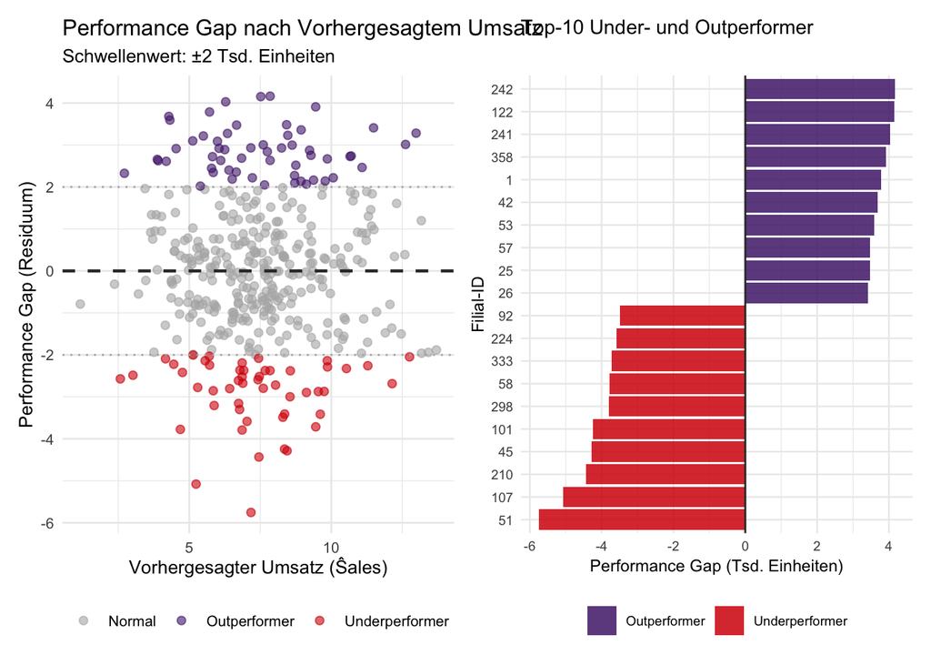

```r
# Plot 1: Scatter Performance Gap vs. Predicted
p1 <- filial_scored %>%
  ggplot(aes(x = Sales_hat, y = performance_gap,
             color = performance_kat)) +
  geom_point(alpha = 0.6, size = 1.8) +
  geom_hline(yintercept = 0, color = "#333",
             linewidth = 0.8, linetype = "dashed") +
  geom_hline(yintercept = c(-2, 2), color = "#b3b2b2",
             linewidth = 0.5, linetype = "dotted") +
  scale_color_manual(
    values = c("Underperformer" = "#D50006",
               "Normal"         = "#b3b2b2",
               "Outperformer"   = "#502479")
  ) +
  labs(
    title    = "Performance Gap nach Vorhergesagtem Umsatz",
    subtitle = "Schwellenwert: ±2 Tsd. Einheiten",
    x        = "Vorhergesagter Umsatz (Ŝales)",
    y        = "Performance Gap (Residuum)",
    color    = NULL
  ) +
  theme_minimal(base_size = 10) +
  theme(legend.position = "bottom")

# Plot 2: Top/Bottom 10 als horizontales Balkendiagramm
p2 <- bind_rows(
  filial_scored %>% arrange(performance_gap) %>%
    head(10) %>% mutate(gruppe = "Underperformer"),
  filial_scored %>% arrange(desc(performance_gap)) %>%
    head(10) %>% mutate(gruppe = "Outperformer")
) %>%
  ggplot(aes(x = reorder(factor(ID), performance_gap),
             y = performance_gap, fill = gruppe)) +
  geom_col(alpha = 0.85) +
  geom_hline(yintercept = 0, color = "#333",
             linewidth = 0.5) +
  scale_fill_manual(values = c("Underperformer" = "#D50006",
                               "Outperformer"   = "#502479")) +
  coord_flip() +
  labs(
    title = "Top-10 Under- und Outperformer",
    x     = "Filial-ID",
    y     = "Performance Gap (Tsd. Einheiten)",
    fill  = NULL
  ) +
  theme_minimal(base_size = 9) +
  theme(legend.position = "bottom")

p1 + p2
```

**Vorsicht A2 — Visualisierung interpretieren**

**1.** Gibt es eine **Systematik**: Sind Filialen mit hohem vorhergesagtem Umsatz eher Outperformer, oder ist die Verteilung gleichmäßig?

**2.** Berechnen Sie Performance-Scores **getrennt nach ShelveLoc**:

```r
filial_scored %>%
  left_join(
    tbl_carseats %>% mutate(ID = row_number()) %>%
      select(ID, ShelveLoc),
    by = "ID"
  ) %>%
  group_by(ShelveLoc) %>%
  summarise(
    mean_gap = round(mean(performance_gap), 3),
    sd_gap   = round(sd(performance_gap),   3),
    n_under  = sum(performance_kat == "Underperformer"),
    n_over   = sum(performance_kat == "Outperformer"),
    n_total  = n()
  )
```

**3.** Ein **Outperformer mit Bad-Regalplatz** könnte interessant sein: Warum? Was würde das Management mit dieser Information tun?

### 3.5 Schritt 5 — Modell-Evaluation

**Code anzeigen**

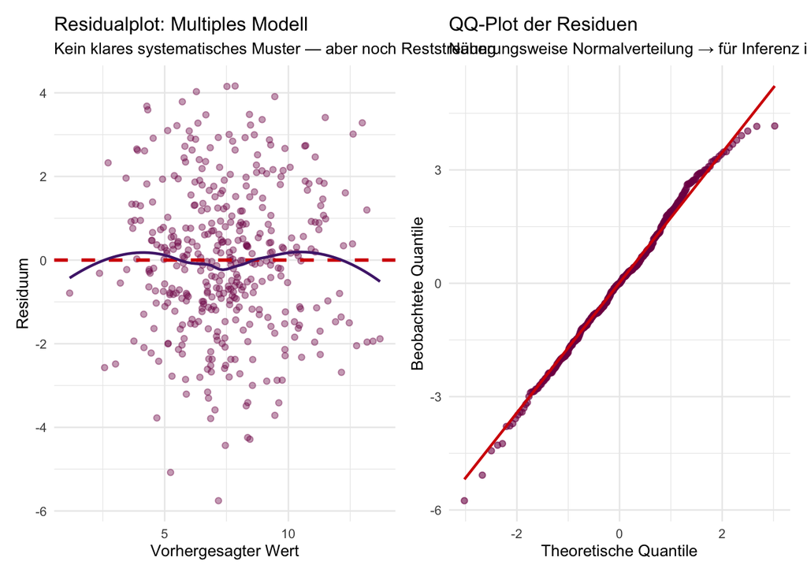

```r
pts <- augment(mod_multipel, data = tbl_carseats)

# Residualplot
p_res <- pts %>%
  ggplot(aes(.fitted, .resid)) +
  geom_point(alpha = 0.4, color = "#7d0a52", size = 1.5) +
  geom_hline(yintercept = 0, color = "#D50006",
             linewidth = 1, linetype = "dashed") +
  geom_smooth(method = "loess", color = "#502479",
              se = FALSE, linewidth = 0.8) +
  labs(title = "Residualplot: Multiples Modell",
       subtitle = "Kein klares systematisches Muster — aber noch Reststreuung",
       x = "Vorhergesagter Wert", y = "Residuum") +
  theme_minimal(base_size = 10)

# QQ-Plot
p_qq <- pts %>%
  ggplot(aes(sample = .resid)) +
  stat_qq(color = "#7d0a52", alpha = 0.6) +
  stat_qq_line(color = "#D50006", linewidth = 0.8) +
  labs(title = "QQ-Plot der Residuen",
       subtitle = "Näherungsweise Normalverteilung → für Inferenz in PVA2 wichtig",
       x = "Theoretische Quantile", y = "Beobachtete Quantile") +
  theme_minimal(base_size = 10)

p_res + p_qq
```

**Code anzeigen**

```r
# Drei-Modell-Vergleich
mod_basis <- lm(Sales ~ Price, data = tbl_carseats)
mod_adv   <- lm(Sales ~ Price + Advertising, data = tbl_carseats)

bind_rows(
  get_regression_summaries(mod_basis) %>%
    mutate(modell = "① Sales ~ Price"),
  get_regression_summaries(mod_adv) %>%
    mutate(modell = "② Sales ~ Price + Advertising"),
  get_regression_summaries(mod_multipel) %>%
    mutate(modell = "③ Sales ~ Price + Advertising + ShelveLoc")
) %>%
  select(modell, r_squared, adj_r_squared, rmse) %>%
  gt() %>%
  fmt_number(columns = c(r_squared, adj_r_squared, rmse),
             decimals = 4) %>%
  tab_style(
    style     = cell_fill(color = "#fff8e1"),
    locations = cells_body(rows = 2)
  ) %>%
  tab_style(
    style     = cell_fill(color = "#f0fff0"),
    locations = cells_body(rows = 3)
  ) %>%
  tab_options(table.font.size = "13px") %>%
  tab_header("Modellvergleich: R²-Progression")
```

Modellvergleich: R²-Progression

| modell | r_squared | adj_r_squared | rmse |
| --- | --- | --- | --- |
| ① Sales ~ Price | 0.1980 | 0.1960 | 2.5260 |
| ② Sales ~ Price + Advertising | 0.2820 | 0.2780 | 2.3903 |
| ③ Sales ~ Price + Advertising + ShelveLoc | 0.6080 | 0.6050 | 1.7649 |

**Vorsicht A3 — Modell-Evaluation**

**1. Residualplot:** Ist das ShelveLoc-Muster aus Lab 2 verschwunden? Welche Reststreuung sehen Sie noch?

| Kategorie | Beispiele |
| --- | --- |
| Im Datensatz vorhanden, noch nicht im Modell | ? |
| Extern beschaffbar (Commodity Data) | ? |
| Nur eigene Erhebung möglich (Proprietary Data) | ? |

## 4 Gruppenaufgabe: Managerial Memo

**Vorsicht Gruppenarbeit (3–4 Personen, 15 Minuten)**

### 4.1 Auftrag

Schreiben Sie ein kurzes **Memo an den Geschäftsführer** (max. 300 Wörter). Sie sind das Data-Science-Team — der GF ist kein Statistiker.

Beantworten Sie alle drei Fragen klar, präzise und managementtauglich.

### 4.2 Frage 1 — Modell-Evaluation: Ist R² ausreichend?

**Was macht eine starke Antwort aus?**

[output not shown]

### 4.3 Frage 2 — OVB: Welche Variablen fehlen?

> *„Welche Faktoren fehlen in unseren Daten, die erklären könnten, warum eine Filiale underperformt? Nennen Sie drei konkrete Beispiele mit Begründung.”*

**Was macht eine starke Antwort aus?**

[output not shown]

### 4.4 Frage 3 — Data Strategy: Make or Buy?

> *„Sollen wir externe Geodaten und Demografiedaten von einem Datenhändler einkaufen (Commodity Data) oder eine eigene Kundenbefragung aufbauen (Proprietary Data)? Argumentieren Sie mit dem AI-Value-Creator-Konzept aus Thomas et al. (2025).”*

**Was macht eine starke Antwort aus?**

[output not shown]

## 5 Debrief: Make-or-Buy und Expected Value Framework

### 5.1 Wann lohnt sich Dateneinkauf?

$$\underbrace{E[\Delta\text{Gewinn}]}_{\text{Mehrwert besserer Entscheidungen}} > \underbrace{C_{\text{Daten}}}_{\text{Beschaffungskosten}}$$

| Parameter | Wert |
| --- | --- |
| Kosten Demografiedaten (Commodity) | 50.000 EUR/Jahr |
| Kosten falsche Filialschließung | 500.000 EUR |
| P(Fehlentscheidung ohne Daten) | 30% |
| P(Fehlentscheidung mit Daten) | 10% |
| E[Δ Gewinn] | (0.30 − 0.10) × 500.000 = **100.000 EUR** |
| Entscheidung | ✅ Datenkauf lohnt sich — 100.000 > 50.000 |

**HinweisVom AI User zum AI Value Creator**

Das Pilotprojekt (heute) hat gezeigt: **Commodity Data** (öffentlicher Carseats-Datensatz) reicht für einen Proof-of-Concept — aber nicht für nachhaltige Wettbewerbsvorteile.

Der Weg zum **AI Value Creator** (Thomas et al., 2025):

1. **Kurzfristig:** Externe Geodaten einkaufen (Commodity) → Modell verbessern
2. **Mittelfristig:** Loyalty-Programm aufbauen → eigene Transaktionsdaten
3. **Langfristig:** Modell mit Proprietary Data trainieren → nicht kopierbar

## 6 CRISP-DM: Abschluss

| Phase | Ergebnis |
| --- | --- |
| ① Business Understanding | Underperformer = Filiale mit stark negativem Residuum |
| ② Data Understanding | EDA: Sales leicht rechtsschief, ShelveLoc als Confounder |
| ③ Data Preparation | ShelveLoc als Dummy-Variable, Advertising aufgenommen |
| ④ Modeling | Multiples Modell: R² ≈ 0.61 \| drei Prädiktoren |
| ⑤ Evaluation | Residualplot: OVB behoben, kein ShelveLoc-Muster mehr |
| ⑥ Deployment | Underperformer-Ranking + Managerial Memo + Make-or-Buy |

**WichtigKernbotschaften dieses Labs**

**HinweisAusblick: Was kommt in PVA2?**

Heute haben wir **deskriptiv** gearbeitet: alle 400 Filialen = Grundgesamtheit (Population).

**Offene Frage:** Was wenn die 400 Filialen nur eine **Stichprobe** wären? Wie sicher sind unsere Koeffizienten? Hätten wir bei einer anderen Saison dieselben Ergebnisse? Und wie wahrscheinlich ist es, dass der gemessene Werbeeffekt nur Zufall ist?

Das sind die Fragen der **statistischen Inferenz** — das Thema von PVA2: Bootstrap, Konfidenzintervalle, p-Hacking, FDR und das Expected-Value-Framework für Manager.